# Capturing Individual differences in learning

Theodros H.

10/2021

# Abstract

# Objectives

This report describes the four ACT-R models and the learning outcomes produced by the changes in parameters. The report also describes how these models fit behavioral data and details the properties of the best fitting models and parameters. The specific objectives of this project is to test if the RLWM task can be modeled well by a group of pure and combined declarative and RL learning models. After fitting the models to participant data we aim to extract parameters that may explain why and how learning resulted as observed. If the parameters describe individual differences in learning would the parameters predict other behavioral data like working memory capacity and reinforcement learning accuracy?

## Approach

The models are fit to behavioral data and the best-fitting model and set of parameters is selected by comparing BIC. The lowest BIC value determines the winning model. To assess the quality of the fit model and parameters RLWM task learning features were compared to the model outcomes. The features of interest are: - Accuracy at the end of learning (accuracy after 12 stimulus presentations) - Accuracy at test - Change in accuracy from end of learning to test - Learning rate - Differences in the learning trajectories of the two set sizes The expectations and outcomes are described below.

# Results

### Model fits

Of the four models compared, the LTM model fit the most number of participants (54) followed by the biased version of the combined RL-LTM model (18) and the meta-RL combined model in third place (10). The RL only model had only one participant that fit it best (figure 1). This is a slight departure from out expectation that the combined RL-LTM models would fit the majority of participants. As observed, this suggests that most learners simply commit to memory the stimulus response associations.

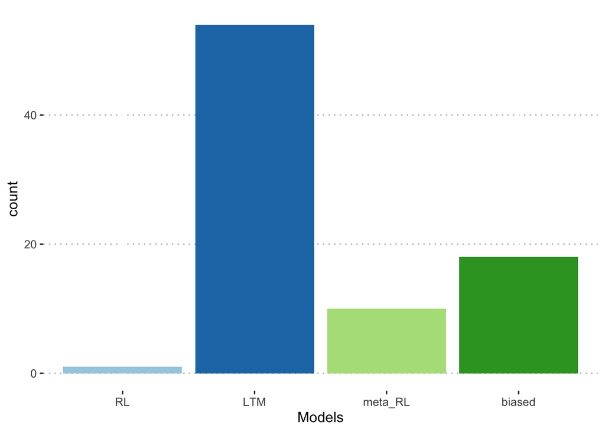

Counts of participants by model

Within each group (groups formed by preferred model types) of participants, there is only 1 RL best fitting combination of parameter values for the alpha and softmax parameters. For the most popular model, LTM, that fit (54) participants, surprisingly, there were only 13 best fitting parameter-value sets for the spreading activation, retrieval noise and memory decay rate parameters. The biased model was the most diverse at 17 parameter sets for (18) participants. The meta-RL model closely followed the biased model in-terms of diversity of parameter-value sets at 8 parameter-value sets for (10) subjects. Figures 2 and 3 show the medians and ranges of the BIC values that determined that the LTM model is the best fitting model even when only comparing BIC values for the set of parameter-values that fit participants best in each category of models.

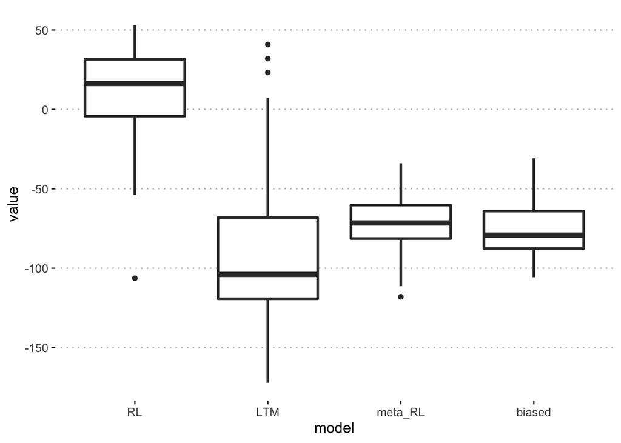

‘BIC: All participants’

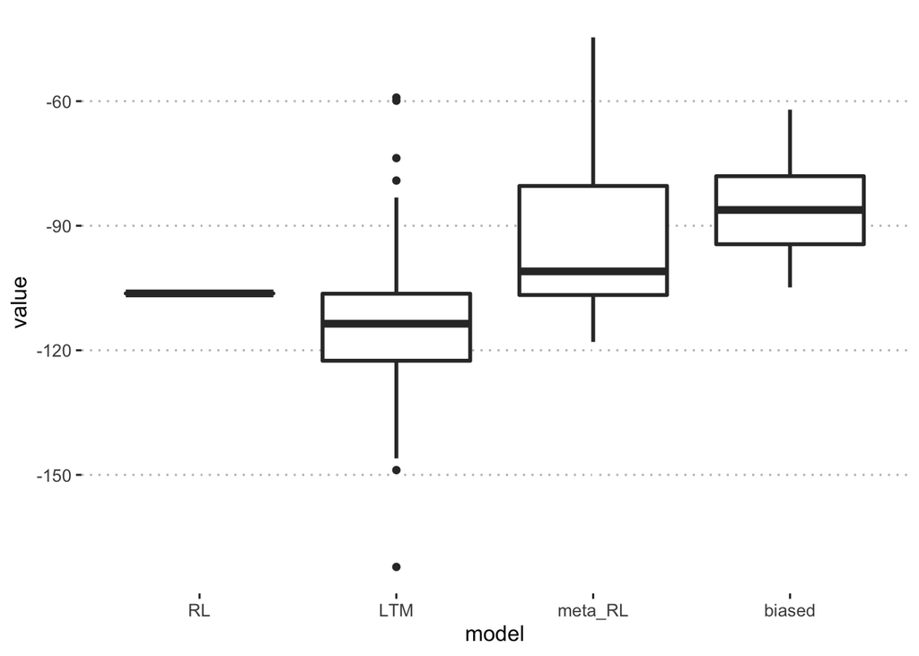

BIC: best fitting per model

How consistent are the fits observed above?

To assess the reliability and stability of the model fitting procedure, the BIC values for each participant model comparison were ranked and compared. Taking the differences in BIC for each consecutive best fit model we found that the difference in BIC value for the best fitting and second best fitting model approached strong evidence against the second model (M= 9.46; SEM=1.18). This difference fell sharply when comparing the 2 with the 3rd best fitting models (M=5.21; SEM= 0.6) and 3rd with 4th (M=3.13, SEM=0.48). To test for stability we looked at how often a model from the same family was selected in the first 10 ranked best fit models.

| model | mean | median | sd | min | max |
| --- | --- | --- | --- | --- | --- |
| biased | 16.00000 | 7.5 | 20.71657 | 2 | 70 |
| LTM | 29.14815 | 7.5 | 43.52115 | 2 | 115 |
| metaRL | 22.50000 | 7.5 | 33.17044 | 2 | 107 |
| RL | 7.00000 | 7.0 | NA | 7 | 7 |

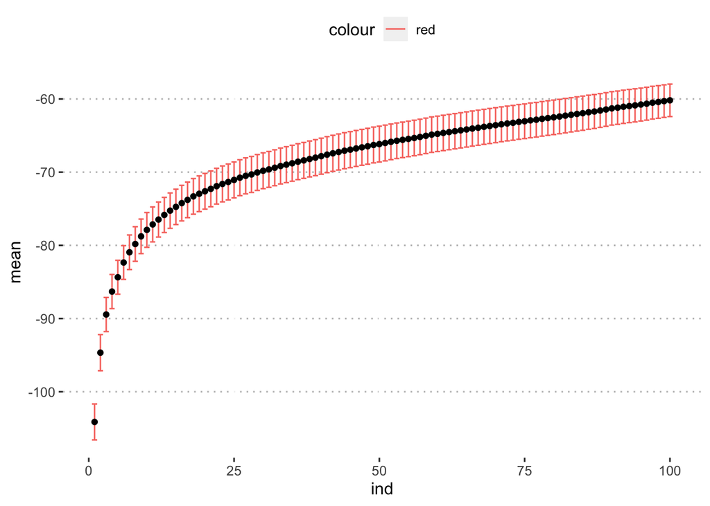

mean BIC for subsequent models

These results indicate that the best fitting model selected for each participant has strong evidence of fit against the subsequent models or parameter-sets (for subjects whose second best fit model also is in the same model family). This pattern of results varies when split by model type. Not surprisingly, participants that fit the LTM model best have the strongest evidence against the 2nd and subsequent models at a mean difference of 12.6 (SEM=1.62). The two integrated models, biased and meta-RL have weak evidence against the second best-fit model at mean BIC difference of 3.53 (SEM= 1.01 ) and 3.57 (SEM=0.94) respectively. The RL model fit has moderate evidence against other models at a mean difference of 4.18 (recall that there is only one participant).

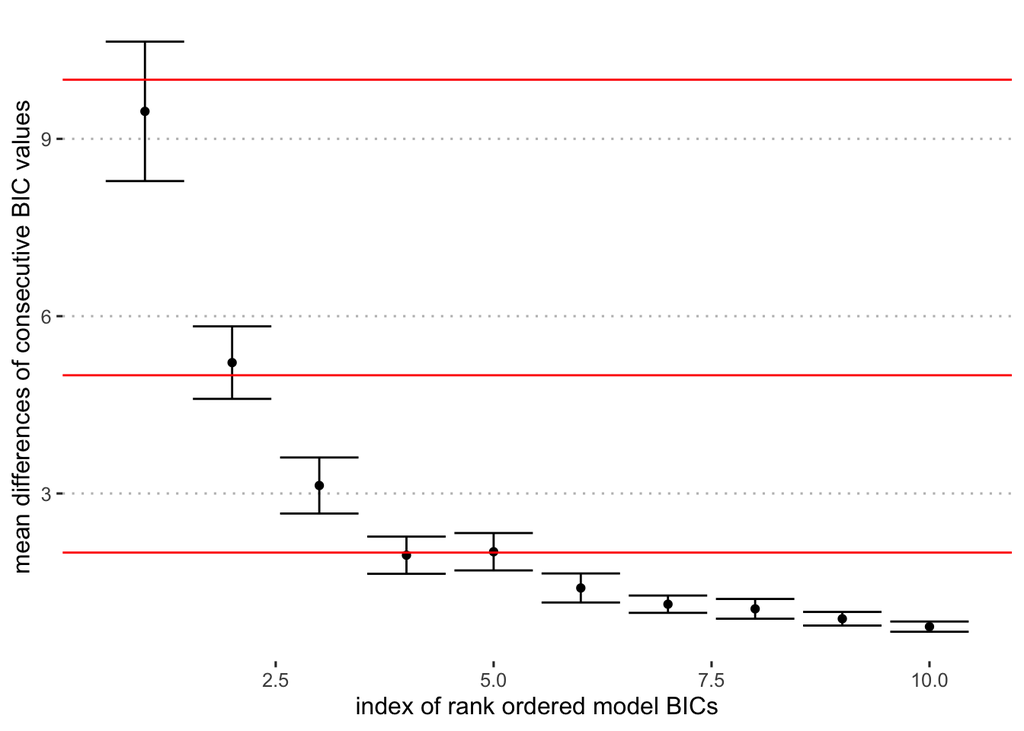

mean differences for ranked consecutive BIC values

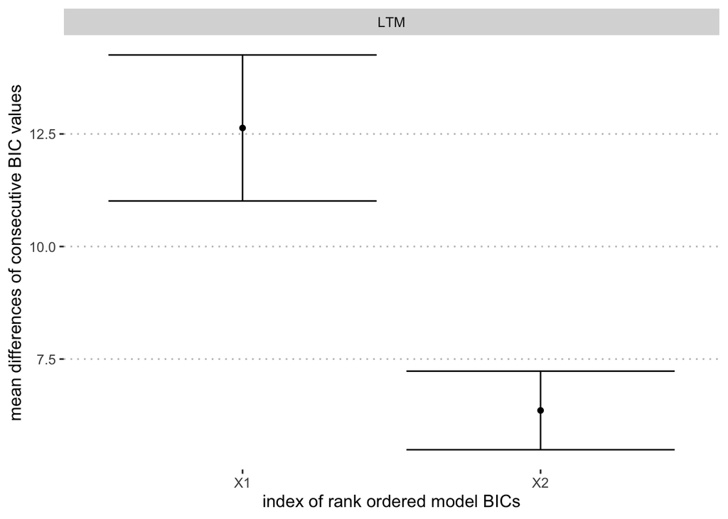

Differences in BIC values by model type.

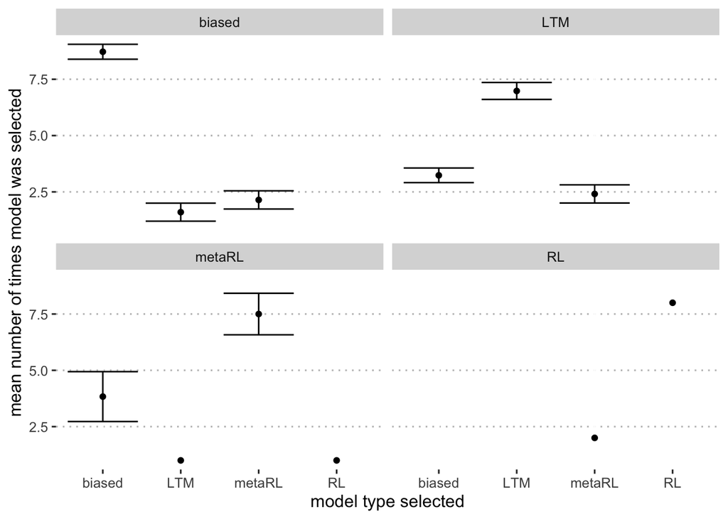

The frequency of model occuring as best fit in the first, ranked, 10 models.

| subjects | X1 | X2 | X3 | model |
| --- | --- | --- | --- | --- |
| 6209 | 0.3835607 | 4.5885937 | 1.8903284 | biased |
| 6231 | 13.4544158 | 5.2886433 | 1.1094847 | LTM |
| 6234 | 25.2794767 | 1.2106092 | 0.3310663 | LTM |
| 6235 | 13.4538969 | 3.9865741 | 4.8191421 | biased |
| 6241 | 6.9816209 | 2.6221561 | 1.8669564 | metaRL |
| 15001 | 15.9719760 | 14.1763784 | 0.0770518 | LTM |
| 15004 | 0.7905286 | 2.9912596 | 1.4152323 | metaRL |
| 15015 | 4.0968626 | 1.8076198 | 2.3458932 | metaRL |
| 28307 | 25.0758619 | 0.8837227 | 0.1963839 | LTM |
| 29305 | 2.8349094 | 9.8399144 | 0.4102510 | biased |

### Assessments of Model fits

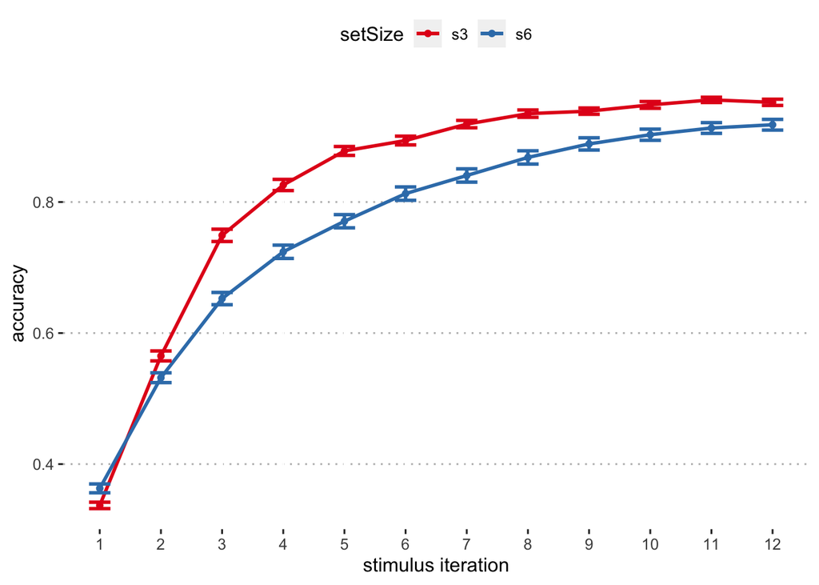

Mean group learning performance.

Looking at the learning curves for the four models in Figure 4, the differences in learning rates are apparent as are other features like the separation between the two set sizes. In the plot below each data point is the average accuracy, for that number of stimulus presentations, across all parameter combinations. The LTM and RL models predict that an increase in set-size does not diminish learning rate and accuracy. But this analysis washes out the individual differences that could be captured by the diverse set of parameter combinations.

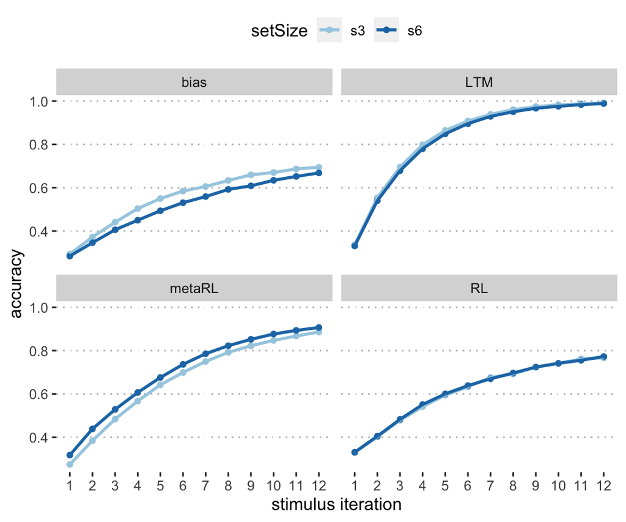

Figure displays model data only averaged across all explored parameters

The panels in figure 5 show the mean accuracy for participant behavioral data. The model lines are averages across parameters for that group only.

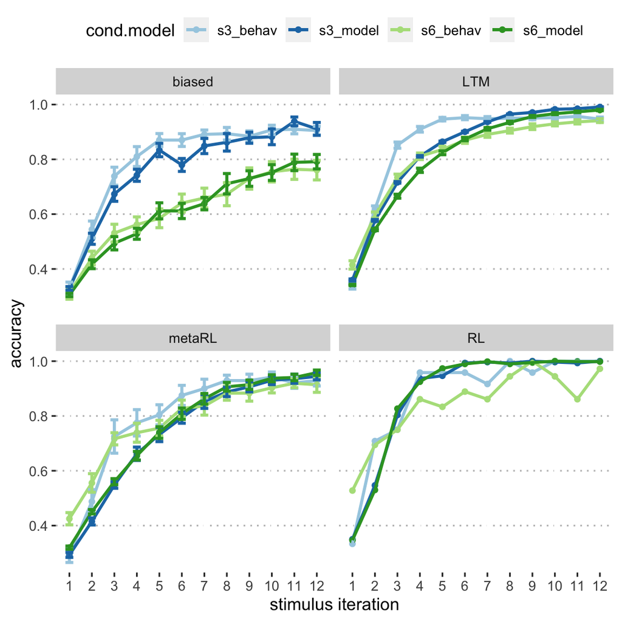

Learning performance for subjects after modelfitting and categorization into model family of best fit model.

As we are aiming for an individual differences look at these data, collapsing across so much of this variability is uninformative, as was shown above in figure 4,especially if the differences, once fit to actual behavioral data, indicate large differences in learning outcomes or cognitive faculty diagnostics like working memory capacity. Here, only the best fitting sets of parameter combinations were selected and collapsed. As can be seen in the figure below, the different model types appear to be vastly different and some characteristics of behavioral data have come through, such as the separations of the learning trajectories for the different setsizes in the RL-LTM Biased model fit. It can also be seen that some parameter sets in the LTM model also capture the difficulty associated with increasing set size (solid lines in Fig. 5B). The LTM participants, on average have the highest accuracies for the testing phase in both set sizes but they are nearly indistinguishable from the meta-RL group for accuracy at end of learning. The biased group shows the most separation between the set size 3 and 6 at learning and also lower accuracy at test than LTM. The biased group is negligibly different from the meta-RL group for set size 3 but shows a marked difference at set size 6, closely following the behavioral data.

### Individual differences in the 5 outcome measures

There are five outcome measures of interest in the RLWM task: accuracy at the end learning, accuracy at test, learning rate characterized as number of stimulus presentations to reach 85% accuracy and beta estimate for the first 6 trials, the differences in learning of set3 and set 6 and also the level of preserved learning at test for both set-sizes. The following analyses compare the model data with behavioral data.

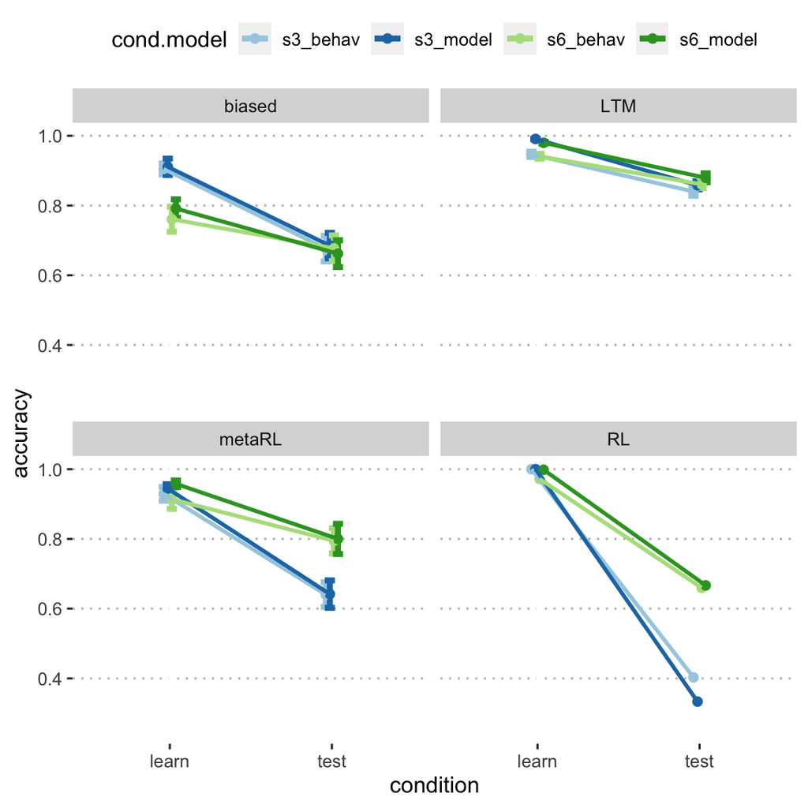

Capturing the change from learing to test to measure forgetting in tasks. These are categorized by model family.

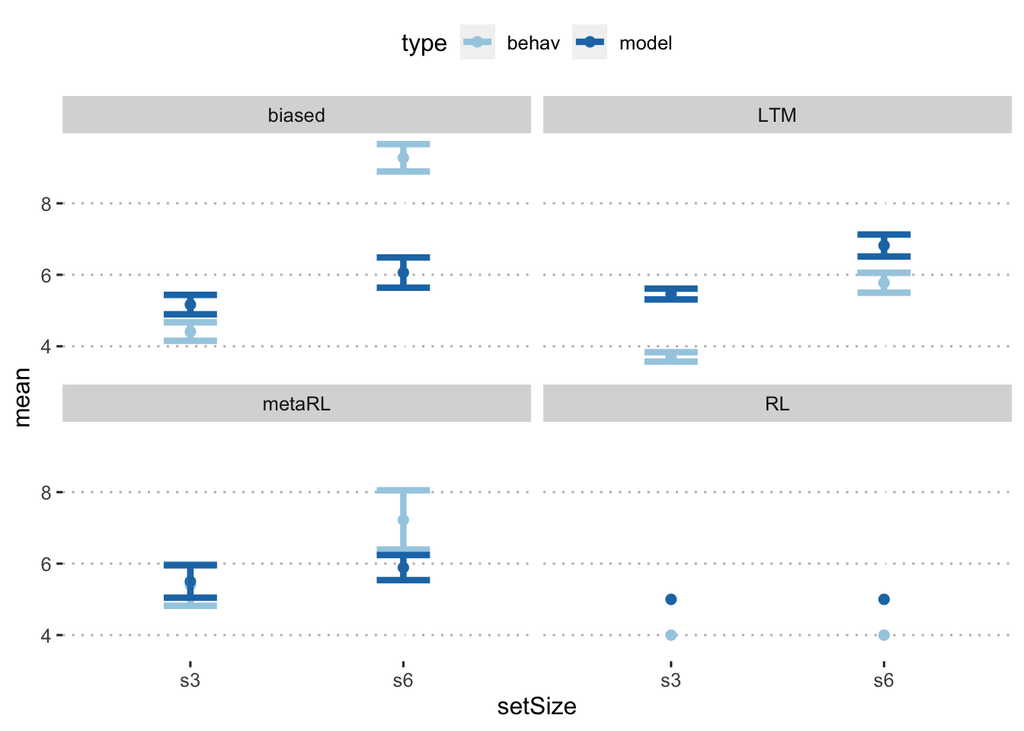

Learning rate captured by number of trials to reach 85% accuracy

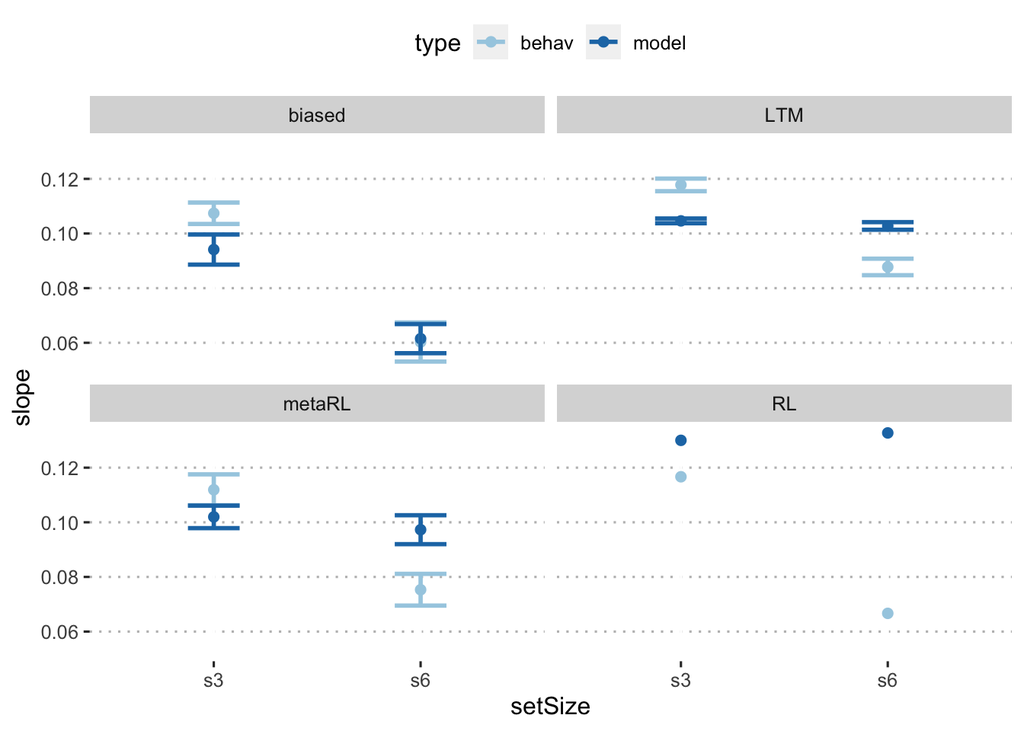

Alternative learing rate: slope of the first 6 iterations of the stimulus. This version would also capture deteriorations i learning.

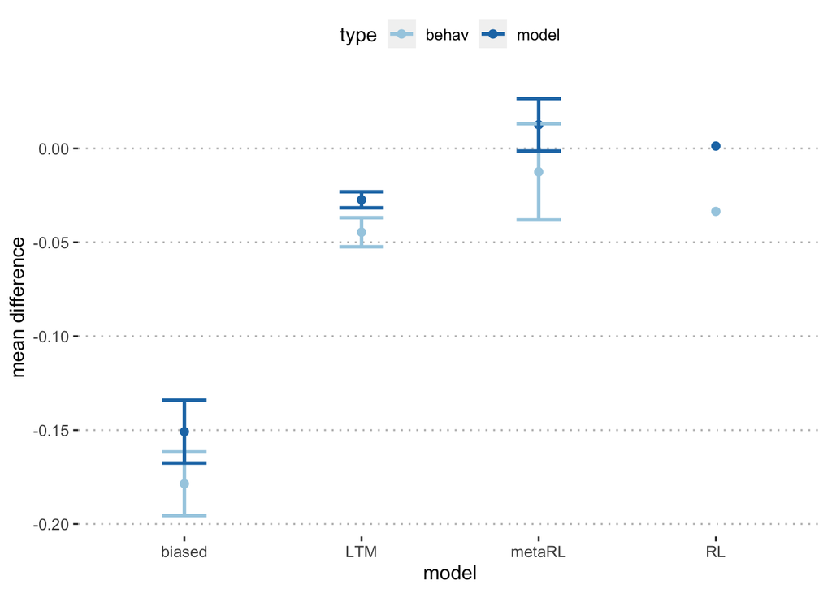

Difficulty of the set size increase could be captured by measuring the separation of the two learing curves rather than looking at final learning outcomes only.

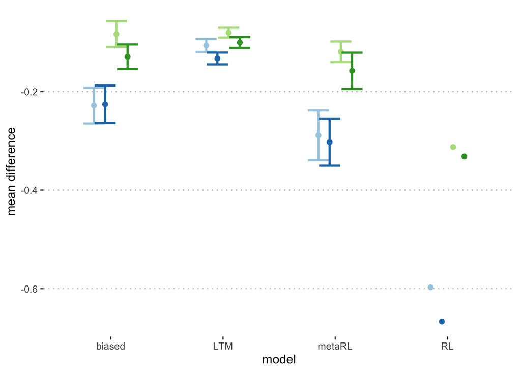

hange from training to test: test - learn

## Parameters

### Parameter spread

Parameter summary: what is the spread of the parameters across participants in the models?

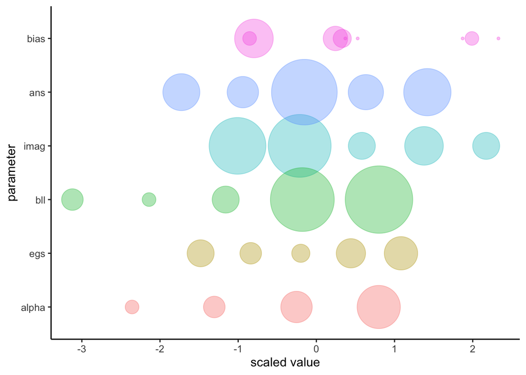

Exploration of the estimated parameters. This ignores the spefic model type that estimated the parameter

### Individual parameter effects on outcomes

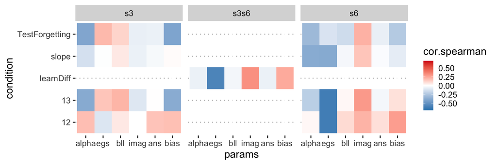

correlation between estimated parameters and measured outcomes: Spearman’s

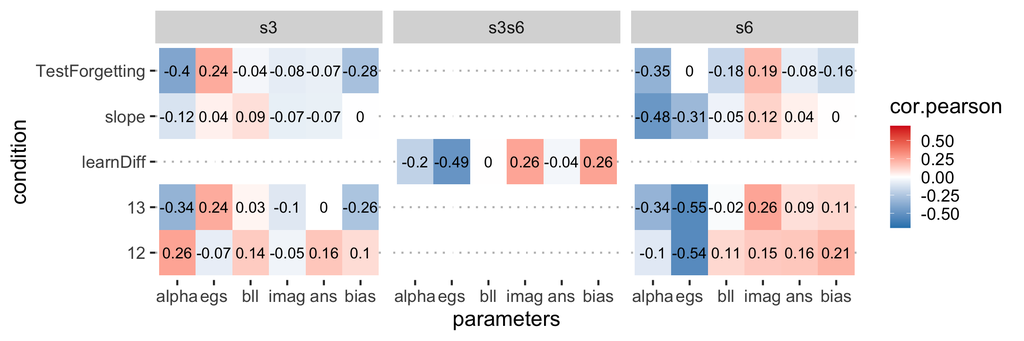

correlation between estimated parameters and measured outcomes: Pearson’s r